# Units, Prefixes, and Dimensional Analysis — Teacher Guide

## Cover

**Unit: Math in Science — Lesson 04: Units, Prefixes, and Dimensional Analysis** East Meadow Schools × Valley Stream Central High School District Strategy chips: HOCHMAN

## Curated Resources (from East Meadow Scope & Sequence)

### NYSSLS Standards

This is a foundational math-skills lesson with no single NYSSLS performance expectation of its own. It develops the science and engineering practice **“Using Mathematics and Computational Thinking,”** required everywhere in **HS-PS** — students must report acceleration in m/s², energy in joules, and current in amperes, and they must catch a wrong answer by noticing the units don’t work out. The crosscutting concept in focus is **Scale, Proportion, and Quantity**: metric prefixes rescale a base unit by powers of ten, and dimensional analysis keeps a quantity’s meaning intact while its units change.

### Phenomenon

- A recipe / road sign with mixed units that must be reconciled — e.g., a European recipe in grams and milliliters, or a speed-limit sign in km/h that a US driver reads as mph.
- NIST “SI Units” primer for the base units and prefixes: https://www.nist.gov/pml/owm/metric-si/si-units

### Javalab / Labs

- **Unit-conversion station** (this lesson’s investigation): convert a mixed-unit recipe or trip so every quantity shares one system.
- Optional: measure a hallway in meters, then convert to cm, mm, and km to feel the prefix ladder.

### Assessments

- The Exit Ticket below (a prefix conversion + a factor-label conversion with a unit check) is the formative check for this lesson.

## Lesson Overview

| **Duration** | 42 minutes (1 period) |
| --- | --- |
| **NYSSLS link** | Practice: Using Mathematics and Computational Thinking (supports all HS-PS) |
| **CCC focus** | Scale, Proportion, and Quantity — prefixes rescale by powers of ten; units carry meaning |
| **Strategy chips** | HOCHMAN (appositive + Because/But/So on the role of units) |
| **Materials** | A mixed-unit recipe or road sign (projected/printed); metric prefix reference; calculators; whiteboards |
| **Safety** | No hazards. |
| **Prior knowledge** | Powers of ten (Lesson 03); multiplying fractions; the idea of canceling. |

**Lesson objectives — students can:**

- Name the **SI units** for length, mass, and time (meter, kilogram, second) and the quantities they measure.
- Convert between units using a **metric prefix** (k, c, m, μ, M) by moving the decimal the right number of places.
- Use **dimensional analysis** (the factor-label method) to convert a compound unit (e.g., km/h → m/s) and check that the units cancel correctly.

## Phase 1 · Engage *(0 – 8 min)*

### 0–3 min · Opening Connection (SEL)

Quick check-in. Prompt: *“Tell us about a time a misunderstanding about ‘how much’ or ‘how big’ caused a problem (a recipe, a road trip, a measurement).”* This sets up that units, not just numbers, carry meaning.

### 3–8 min · Phenomenon hook — the mixed-unit recipe / road sign

**Teacher actions.** Project a recipe that lists “250 g flour, 0.2 L milk, 15 mL oil, bake at 180 °C” next to US measuring cups and an oven in °F — or a “100 km/h” sign next to a US speedometer in mph.

[figure not shown]

**Sample teacher language:**

> “This recipe and your kitchen don’t speak the same language. The recipe says 250 grams; your scoop says cups. The sign says 100 kilometers per hour; your speedometer says miles. Same physical amount — different units. Today we become the translators, and we’ll do it so carefully the *units themselves* tell us when we’re right.”

**Anticipated student responses:**

- “Just look it up / use Siri.” — affirm the instinct, then: “Siri doesn’t show its work, and on the Regents you do — let’s see the machinery.”
- “Grams and cups aren’t the same thing.” — exactly; one’s mass, one’s volume — units track *what kind* of quantity.
- “Kilo means a thousand, right?” — yes, capture it; that’s the prefix ladder.

### Bridge to Phase 2

Every student leaves Phase 1 able to state the goal: “Rewrite every quantity in *one* consistent system without changing the actual amount.”

## Phase 2 · Explore *(8 – 26 min)*

### 8–14 min · Skill A — SI base units and the prefix ladder

Establish the three core **SI units**: meter (length), kilogram (mass), second (time). Then build the **prefix ladder** — each rung is a power of ten.

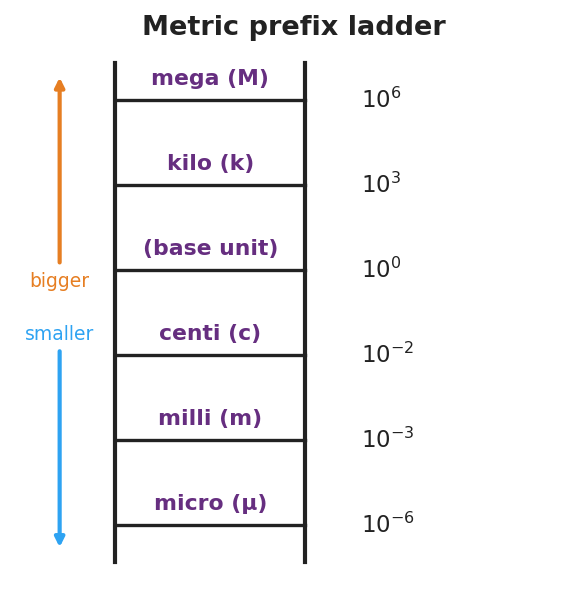

Metric prefix ladder

**Teacher facilitation language:**

> “Going *up* a prefix means a bigger unit, so it takes *fewer* of them — 1500 m is only 1.5 km. Each rung is the decimal hopping by powers of ten. How many places, and which way?”

**Anticipated student responses:**

- “1 km = 100 m?” — common slip; kilo is 10³ = 1000, not 100.
- “Micro is the tiny one.” — yes, μ = 10⁻⁶; pair it with a gesture.

### 14–26 min · Skill B — dimensional analysis (factor-label)

Model converting 90 km/h → m/s by multiplying by “1” written as a ratio (1000 m / 1 km)(1 h / 3600 s) so the unwanted units **cancel**. Then groups convert the recipe / road-trip quantities.

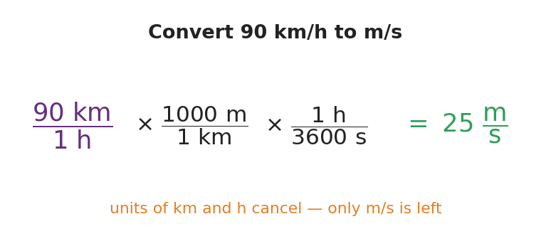

Convert 90 km/h to m/s with factor-label

**Teacher facilitation during Explore:**

- **What to look for** — students writing the conversion factor so the *old* unit lands on the bottom and cancels.
- **What to resist** — letting them “just multiply by 1000” from memory; insist on writing the labeled ratio so the units do the checking.
- **What to redirect** — answers where km didn’t cancel (unit ends up km·m/h); have them flip the offending factor.

## Phase 3 · Explain *(26 – 34 min)*

### 26–30 min · Turn-and-Talk + class consensus

> “When you multiply by (1000 m / 1 km), why are you *allowed* to — and how do you know which way to write it? Use the word *cancel*.”

Target consensus:

> “1000 m equals 1 km, so that ratio equals 1 — multiplying by 1 doesn’t change the amount, only the units. We write it with km on the bottom so the km we started with cancels, leaving meters.”

### 30–34 min · Vocabulary introduction (≤ 3 terms)

**Sample teacher language:**

> “Three words make every conversion safe. An **SI unit** is the agreed scientific unit for a quantity — meter, kilogram, second. A **metric prefix** — like kilo or milli — rescales that unit by a power of ten. And **dimensional analysis** is the factor-label method: you multiply by ratios that equal 1 so the unwanted units cancel and the units of your answer prove it’s right.”

### Discussion prompts to deploy here

- “How is multiplying by (1 h / 3600 s) different from just dividing by 3600?”
  - *Sample student response:* “It’s the same arithmetic, but the labeled ratio shows the hours cancel, so I can’t lose track of the units.”
- “If my answer for a speed comes out in km·m/h, what went wrong?”
  - *Sample student response:* “A factor was upside down — km didn’t cancel. Flip it so the unwanted unit is on the bottom.”

## Phase 4 · Elaborate *(34 – 39 min)*

### 34–37 min · HOCHMAN appositive + Because/But/So

Have students define a unit with an appositive, then expand with the conjunctions.

Target appositive: “A newton, *the push that gives 1 kg an acceleration of 1 m/s²*, is the SI unit of force.” Target B/B/S: “…**because** numbers without matching units are meaningless, **but** a prefix or factor-label step can rescale them, **so** I convert first, then compute.”

### 37–39 min · Return to the phenomenon

> “Pick one recipe or road-sign quantity. State it in the US system in one sentence, and name how you knew your conversion was right.”

## Phase 5 · Evaluate *(39 – 42 min)*

### 39–42 min · Exit Ticket + Closing Reflection

> *“(a) Convert 2.5 km to meters. (b) Convert 45 mm to meters (use the prefix). (c) Convert 72 km/h to m/s using the factor-label method, and circle the units that cancel.”*

Expected: (a) 2,500 m; (b) 0.045 m; (c) 72 × (1000 m / 1 km) × (1 h / 3600 s) = 20 m/s, with km and h canceling. See `Answer_Key.docx`.

**Closing Reflection (SEL, 30 seconds):**

> “Where else in your life would ‘check that the units make sense’ have saved you a mistake? Name one.”

## Common Misconceptions

- **Misconception:** “kilo means 100.” → **Correction:** kilo = 10³ = 1000; centi = 10⁻², milli = 10⁻³.
- **Misconception:** “To convert km/h to m/s, just multiply by 1000.” → **Correction:** You must convert *both* the km (→ m) and the h (→ s); 90 km/h = 25 m/s, not 90,000 m/s.
- **Misconception:** “Units are just labels you tack on at the end.” → **Correction:** Units carry the meaning and the math; if they don’t cancel correctly, the number is wrong.
- **Misconception:** “Bigger prefix → bigger number of units.” → **Correction:** A bigger unit needs *fewer* of them — 1500 m is only 1.5 km.

## Strategy Spotlight

**HOCHMAN (sentence-level literacy).** Today’s chip is the appositive plus the Because/But/So expansion in Phase 4. Defining a unit with an appositive (“A newton, *the push that…*, is the SI unit of force”) forces students to pack a precise definition into a single clause — the exact skill the Regents constructed-response rewards. The Because/But/So then makes them articulate *why* units must match and *what to do about it*, turning a procedure into reasoning. Keep responses to one sentence each and collect the most precise appositives aloud.

## NYSSLS Observation Checklist Crosswalk

[output not shown]

## Companion Materials

- `Student_Worksheet.docx` — the 5E student investigation with the recipe/road-trip conversion (hand out at start of Phase 2)
- `Student_Notes.docx` — guided note-guide for prefixes and the factor-label worked example
- `Answer_Key.docx` — answers to “Make It Make Sense” prompts and the Exit Ticket

## Key Vocabulary (max 3)

- **SI unit** — the agreed international scientific unit for a quantity: meter (length), kilogram (mass), second (time)
- **metric prefix** — a word/symbol (k, c, m, μ, M) that rescales a base unit by a power of ten (kilo = 10³, milli = 10⁻³)
- **dimensional analysis** — the factor-label method: multiplying by ratios equal to 1 so unwanted units cancel, leaving the desired units